# L2P2 - Sessões, buscas e navegação na wikimedia

Erick Santana Rodrigues

# 1 Visão geral

Nessa análise usaremos dados sobre padrões de buscas e navegação em páginas de projetos da wikimedia. Vamo dar uma olhada nos dados:

```r
buscas$session_start_timestamp <- NULL
head(buscas %>% arrange(session_id))
```

| session_id | search_index | session_length | session_start_date | group | results | num_clicks | first_click |
| --- | --- | --- | --- | --- | --- | --- | --- |
| 0000cbcb67c19c45 | 1 | 0 | 2016-03-03 | b | 20 | 0 | NA |
| 0001382e027b2ea4 | 1 | 303 | 2016-03-07 | b | 18 | 1 | 1 |
| 0001e8bb90445cb2 | 1 | 435 | 2016-03-05 | b | 20 | 1 | 1 |
| 000216cf18ae1ab1 | 1 | 58 | 2016-03-08 | a | 20 | 0 | NA |
| 000216cf18ae1ab1 | 2 | 58 | 2016-03-08 | a | 20 | 0 | NA |
| 000216cf18ae1ab1 | 3 | 58 | 2016-03-08 | a | 20 | 0 | NA |

- session_id: Um id identificando sessões individuais.
- search_index: Um contador de buscas em uma mesma sessão ordenado cronologicamente.
- session_start_date: A data em que a busca foi feita.
- group: O grupo “a” ou “b”.
- results: A quantidade de resultados que a busca retornou.
- num_clicks: O número de páginas que o usuário visitou a partir da busca.
- first_click: A posição do link da página visitada no mecanismo de busca de páginas.
- session_length: A duração em segundos da sessão.

Através de uma análise exploratória rápida podemos ter uma ideia da quantidade e do comportamento dos dados que estamos lidando. Vamos analisar a quantidade de clicks em cada sessão por grupo, ignorando sessões com duração 0.

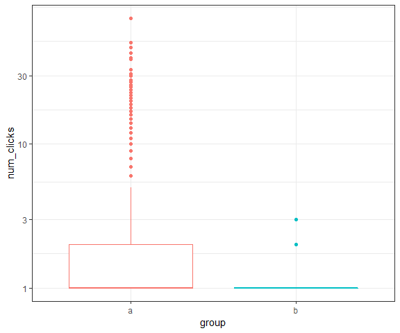

```r
buscas %>%
    filter(session_length > 0) %>%
    group_by(session_id) %>%
    summarise(num_clicks = sum(num_clicks), group = first(group)) %>%
    ggplot(aes(x = group, y = num_clicks, group = group, color = group)) +
    geom_boxplot(show.legend = FALSE) +
    scale_y_log10()
```

Podemos ver que a mediana para ambos os grupos é de 1 clique em cada sessão, porém existem alguns valores muito altos para essa quantidade (outliers) o que pode interferir no valor da média. É possível observar também os dados em a são mais espaçados e possivelmente estão em maior quantidade.

```r
buscas %>%
    group_by(group) %>%
    summarise(numberGroup = n())
```

| group | numberGroup |
| --- | --- |
| a | 92056 |
| b | 44178 |

O grupo ‘a’ tem pouco mais que o dobro de dados que o grupo ‘b’. Agora vamos observar a quantidade de resultados de cada sessão.

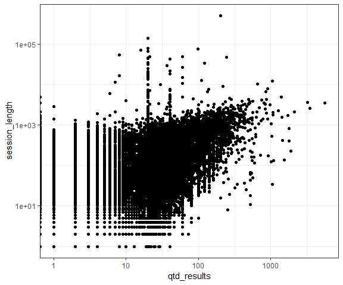

```r
buscas %>%
    filter(session_length > 0) %>%
    group_by(session_id) %>%
    summarise(qtd_results = sum(results), session_length = first(session_length)) %>%
    ggplot(aes(qtd_results, session_length)) +
    geom_point() +
    scale_x_log10() +
    scale_y_log10()
```

Traçando um gráfico entre a quantidade de resultados de cada sessão e o tamanho da sessão (ignorando aquelas com duração 0), não conseguimos enxergar uma relação com muita clareza. Se calcularmos a correlação entre essas duas variáveis veremos que ela é fraca.

```r
correlation = buscas %>%
    filter(session_length > 0) %>%
    group_by(session_id) %>%
    summarise(qtd_results = sum(results), session_length = first(session_length))

correlation %>%
    summarise(pearson  = cor(qtd_results, session_length, method = "pearson"),
              spearman = cor(qtd_results, session_length, method = "spearman"),
              kendall  = cor(qtd_results, session_length, method = "kendall"))
```

| pearson | spearman | kendall |
| --- | --- | --- |
| 0.0532509 | 0.2315436 | 0.1664127 |

# 2 Perguntas

Após uma pequena análise exploratória para conhecer os dados que estamos usando, vamos responder algumas perguntas sobre eles.

## 2.1 Qual é a taxa de cliques geral diária? Como isso varia entre os grupos?

Iremos calcular a quantidade de cliques por sessão e então dividiremos esse valor pelo número total de sessões, desconsiderando aquelas em que não houveram cliques.

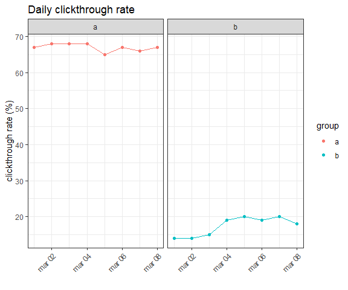

```r
buscasSessao <- buscas %>%
    group_by(session_id, group) %>%
        summarise(session_length = first(session_length),
              date = first(session_start_date),
              sum_clicks = sum(num_clicks))

buscasSessao %>%
    group_by(date, group) %>%
    summarise(click_rate = round(mean(sum_clicks > 0),2)) %>%
    ggplot(aes(x = date, y = click_rate * 100, group = group, color = group)) +
    geom_point() +
    geom_line(show.legend = FALSE) +
    labs(title = "Daily clickthrough rate", x = "", y = "clickthrough rate (%)") +
    theme(axis.text.x = element_text(hjust = 1, angle = 45)) +
    facet_wrap(~group)
```

Agrupando a taxa de cliques por sessão e desconsiderando sessões em que não houveram cliques, podemos ver que para o grupo ‘a’ possui uma taxa de cliques muito maior que o grupo ‘b’, que não passa dos 20%.

## 2.2 Quais resultados as pessoas tendem a tentar primeiro? Como isso muda no dia-a-dia?

Iremos desconsiderar os casos onde a posição do link da página visitada é maior que 25, isso pois a incidência de cliques é bem baixa como podemos ver a seguir.

```r
head(buscas %>%
    filter(first_click >= 25) %>%
    group_by(first_click) %>%
    summarise(count = n()))
```

| first_click | count |
| --- | --- |
| 25 | 6 |
| 26 | 2 |
| 27 | 4 |
| 28 | 7 |
| 29 | 5 |
| 30 | 5 |

Traçando um gráfico de barras, podemos ver que, no geral, a grande maioria das pessoas clica no primeiro link, enquanto que o outros valores estão muito abaixo.

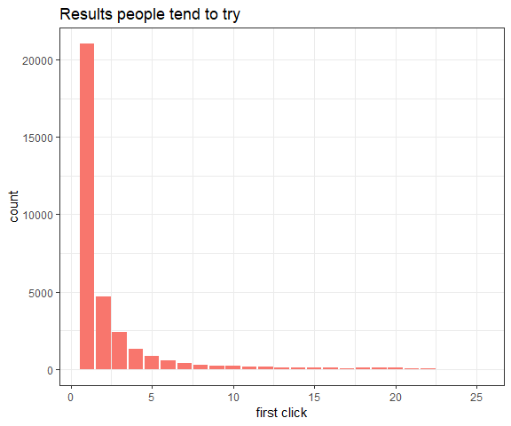

```r
buscas %>%
    filter(first_click <= 25) %>%
    ggplot(aes(x = first_click, fill = "#FF6666")) +
    geom_bar(show.legend = FALSE) +
    labs(title = "Results people tend to try",x = "first click")
```

Para fazer a mesma análise, porém considerando no dia-a-dia, teremos que usar outro valor como medida visto que se usarmos valores dos 50% percentil dos dados ou menos, a grande maioria dos valores será a mesma para todos os dias e nossa visualização não mostrará muita coisa. Vamos utilizar o 95% percentil.

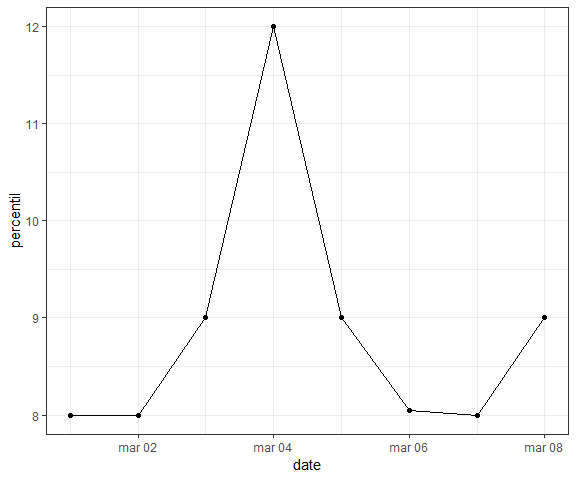

```r
buscas %>%
    group_by(date = session_start_date) %>%
    summarise(percentil = quantile(first_click, c(.95), na.rm = TRUE)) %>%
    ggplot(aes(x = date, y = percentil)) +
    geom_line() +
    geom_point()
```

Podemos ver uma variação considerável entre os dias, para o 95% percentil, sendo o dia 04 de março aquele com o maior valor.

## 2.3 Qual é a taxa diária de resultados zero no geral? Como isso varia entre os grupos?

Para responder essa pergunta, vamos traçar um gráfico entre os dias e a média dos resultados 0, ao dividir por grupos teremos uma visualização que responderá a pergunta.

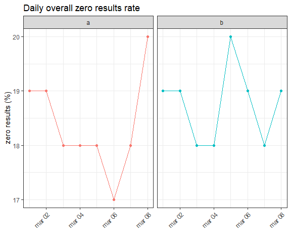

```r
buscas %>%
    group_by(date = session_start_date, group) %>%
    mutate(mean_zero = round(mean(results == 0), 2) * 100) %>%
    ggplot(aes(x = date, y = mean_zero, group = group, color = group)) +
    geom_point(show.legend = FALSE) +
    geom_line(show.legend = FALSE) +
    labs(title = "Daily overall zero results rate", x = "", y = "zero results (%)") +
    theme(axis.text.x = element_text(hjust = 1, angle = 45)) +
    facet_wrap(~group)
```

Podemos ver que os gráficos são idênticos de 04 de março para trás, porém desse dia em diante as taxas de resultado 0 mudam para os grupos. O grupo tem as menores taxas, chegando a 17% das buscas retornando zero. O maior valor, para ambos os grupos, foi de 20%.

## 2.4 Escolha uma variável do conjunto de dados e descreva sua relação com o tamanho da sessão. Visualize o relacionamento.

Vamos analisar a relação entre o tamanho de uma sessão e a quantidade de cliques que ocorrem nela.

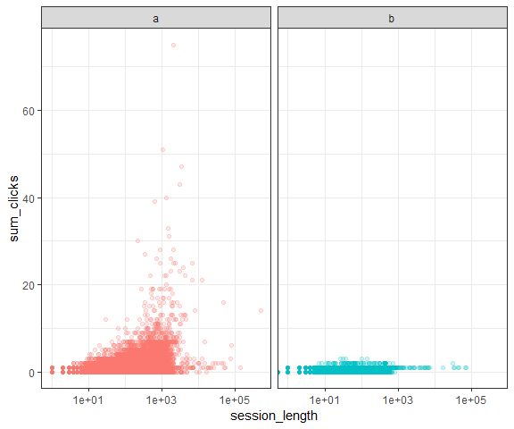

```r
buscasSessao %>%
    ggplot(aes(session_length, sum_clicks, color = group)) +
    geom_point(alpha = .2, show.legend = FALSE) +
    scale_x_log10() +
    facet_wrap(~group)
```

```r
buscasSessao %>%
    group_by(group) %>%
    summarise(pearson  = cor(session_length, sum_clicks, method = "pearson"),
              spearman = cor(session_length, sum_clicks, method = "spearman"),
              kendall  = cor(session_length, sum_clicks, method = "kendall"))
```

| group | pearson | spearman | kendall |
| --- | --- | --- | --- |
| a | 0.0921041 | 0.4188649 | 0.3265668 |
| b | 0.1336444 | 0.7652151 | 0.7117830 |